# Bayesian mini-project: Mixture model for alternative splicing

# EVALUATION

## Posterior Predictive Check global (PPC)

Objective: check if the model can reproduce the distribution of observed y/n.

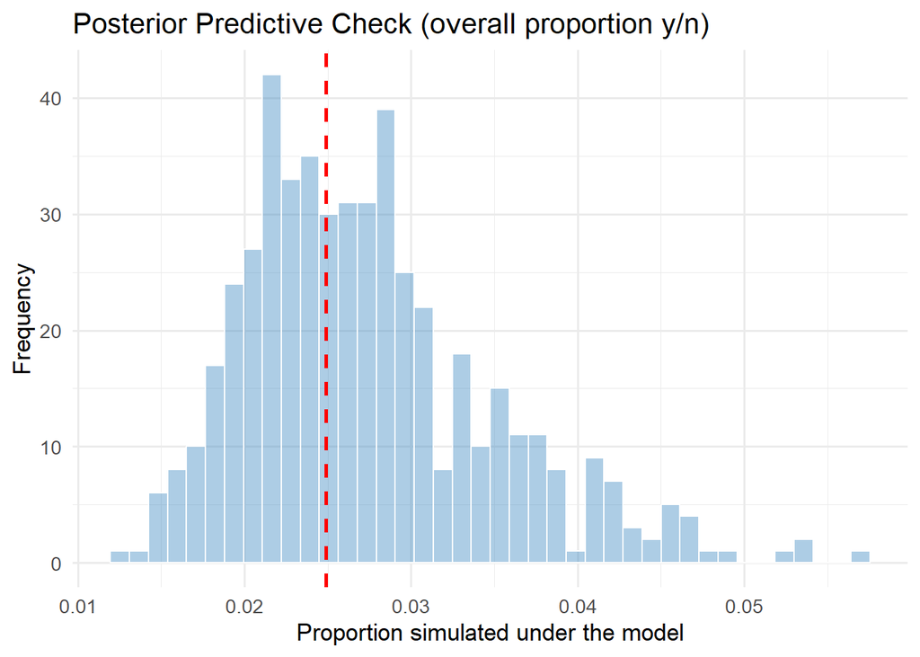

```r
## Posterior Predictive Check global
set.seed(1234)


# Select 500 MCMC samples
draws_ppc <- sample(seq_len(nrow(samps_mat_mix)), size = 500)


# For each sample: simulate new y_rep values
ppc_df <- lapply(draws_ppc, function(k){
  beta0 <- samps_mat_mix[k, "beta0"]
  beta1 <- samps_mat_mix[k, "beta1"]
  beta2 <- samps_mat_mix[k, "beta2"]
  p_s   <- samps_mat_mix[k, "p"]
  a_s   <- samps_mat_mix[k, "a"]
  b_s   <- samps_mat_mix[k, "b"]

  eta <- beta0 + beta1 * jags_data_mix$expr + beta2 * jags_data_mix$introns
  theta_b <- 1/(1+exp(-eta))
  theta_f <- rbeta(jags_data_mix$N, a_s, b_s)
  Z_sim <- rbinom(jags_data_mix$N, 1, p_s)
  theta <- Z_sim * theta_f + (1 - Z_sim) * theta_b
  yrep <- rbinom(jags_data_mix$N, size = jags_data_mix$n, prob = theta)
  return(sum(yrep) / sum(jags_data_mix$n))  # simulated global proportion
})

ppc_df <- data.frame(prop_sim = unlist(ppc_df))
obs_prop <- sum(jags_data_mix$y) / sum(jags_data_mix$n)

ggplot(ppc_df, aes(x = prop_sim)) +
  geom_histogram(bins = 40, fill = "#3182bd", alpha = 0.4, color = "white") +
  geom_vline(xintercept = obs_prop, color = "red", linetype = "dashed", size = 1) +
  labs(title = "Posterior Predictive Check (overall proportion y/n)",
       x = "Proportion simulated under the model",
       y = "Frequency") +
  theme_minimal(base_size = 13)
```

```r
cat("Observed proportion :", round(obs_prop,4), "\n",
    "Simulated 95% interval :", quantile(ppc_df$prop_sim, c(0.025,0.975)), "\n")
```

```
## Observed proportion : 0.0249
##  Simulated 95% interval : 0.01635645 0.04568665
```

## Posterior Predictive Check par classe (“noise” vs “functional”)

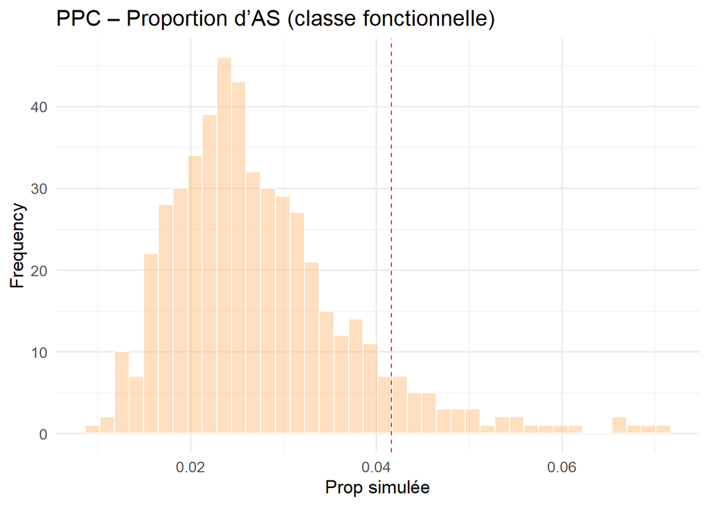

```r
## PPC par classe (functional vs noise selon Z_probs observé)
set.seed(2025)
draws <- sample(seq_len(nrow(samps_mat_mix)), size = 500)

# For each sample: simulate new yrep values and compute prop by class
ppc_class <- sapply(draws, function(k){
  beta0 <- samps_mat_mix[k, "beta0"]
  beta1 <- samps_mat_mix[k, "beta1"]
  beta2 <- samps_mat_mix[k, "beta2"]
  p_s   <- samps_mat_mix[k, "p"]
  a_s   <- samps_mat_mix[k, "a"]
  b_s   <- samps_mat_mix[k, "b"]

  eta <- beta0 + beta1 * jags_data_mix$expr + beta2 * jags_data_mix$introns
  theta_b <- 1/(1+exp(-eta))
  theta_f <- rbeta(length(theta_b), a_s, b_s)
  Z_sim <- rbinom(length(theta_b), 1, p_s)
  theta <- Z_sim * theta_f + (1 - Z_sim) * theta_b
  yrep <- rbinom(length(theta_b), size = jags_data_mix$n, prob = theta)

  idx_func <- which(Z_probs >= 0.9)
  idx_noise <- setdiff(seq_along(theta_b), idx_func)
  c(
    prop_func = sum(yrep[idx_func]) / sum(jags_data_mix$n[idx_func]),
    prop_noise = sum(yrep[idx_noise]) / sum(jags_data_mix$n[idx_noise])
  )
})


ppc_class_df <- as.data.frame(t(ppc_class))
obs_class <- df_small %>%
  mutate(P_func = Z_probs,
         class = ifelse(P_func >= 0.9, "functional", "noise")) %>%
  group_by(class) %>%
  summarise(obs_prop = sum(y)/sum(n))

ggplot(ppc_class_df, aes(x = prop_func)) +
  geom_histogram(bins = 40, fill = "#fdae61", alpha = 0.4, color = "white") +
  geom_vline(xintercept = obs_class$obs_prop[obs_class$class=="functional"],
             color = "red", linetype = "dashed") +
  labs(title = "PPC – Proportion d’AS (classe fonctionnelle)", x = "Prop simulée", y = "Frequency") +
  theme_minimal(base_size = 13)
```

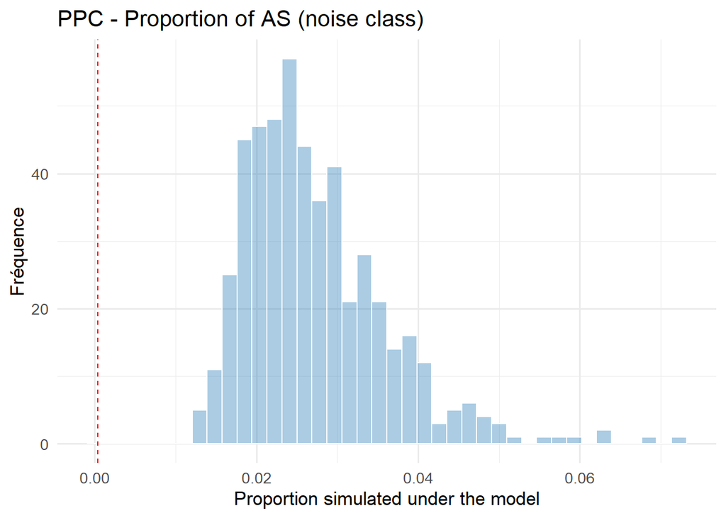

```r
ggplot(ppc_class_df, aes(x = prop_noise)) +
  geom_histogram(bins = 40, fill = "#2c7fb8", alpha = 0.4, color = "white") +
  geom_vline(xintercept = obs_class$obs_prop[obs_class$class=="noise"],
             color = "red", linetype = "dashed") +
  labs(title = "PPC - Proportion of AS (noise class)", x = "Proportion simulated under the model", y = "Fréquence") +
  theme_minimal(base_size = 13)
```

Noise class Blue histogram: simulations for introns classified as noise. The observed (0.0004) is much lower than predicted by the model (simulated distribution centered around 0.02). So the model strongly overestimates the probability of AS from the noise. In other words, the model believes that even “noisy” introns have a proba of AS around 2%, when in reality it is 100 lower.

Why? ’ Several possible reasons:

– Conceptual interpretation The model explains the functional component well, but it does not fully explain the “zero-excess” of noise. In other words, there is not enough mass around 0 for θ_b. The observations have many introns “almost never spliced”, and the model fails to create this “wall at zero”.